# 4.2. Data Pipelines

As we remarked earlier, everything that happens in R happens via functions. For the example in 4.1, the equivalent function calls are:

```r
mtu <- readRDS("mtu2.RDS")

dplyrResult <- dplyr::summarize(
    .data = dplyr::group_by(
        .data = mtu,
        Date = base::as.Date(DateAndTime)
    ),
    Precipitation = base::mean(base::range(Precipitation))
)
```

where we have been explicit about the functions and the packages. (The `::` notation is a way of explicitly specifying a function in a particular R package.)

However, this combining, while efficient, reversed the order of steps in the formulation of the code: to *group first and summarize after*, the function invocation has reflects *summarize what has been grouped*, simply because that is how the actual operation takes place.

When the number of steps are more than two, you can see that this can quickly make for code that is hard to read and maintain.

Why should the sequence of operations not reflect the actual thought process making things more transparent?

This is where pipes come in. Pipes allow for a natural expression of sequential operations, in the order that they should be performed, passing the output of one process as input to another, maintaining *verisimilitude* with the actual sequence of operations.

Many data processing tasks fit a pipe pattern naturally.

# 4.2.1. What are pipes?

```
bash $> head data.csv | cut -d',' -f 2 | sort | uniq
43
51
52
54
55
61
62
69
age
```

# 4.2.2. Enter `magrittr`

The package `magrittr` is designed for creating pipelines in R.

The key construct is the infix operator `%>%` which means pipe the output of one operation into the next.

For example, the grouping and summarizing example could be rewritten using `magrittr` as follows.

```r
library(magrittr)
library(dplyr)
dplyrResult <- mtu %>%
    dplyr::group_by(Date = base::as.Date(DateAndTime)) %>%
    dplyr::summarize(Precipitation = base::mean(base::range(Precipitation)))
```

That’s it.

Compare this to the vanilla R approach, or even the direct `dplyr` approach. Clearly the combination of `dplyr` together with the piping syntax is cleaner and attractive and leads to code that is transparent and easy to understand. In the long run, such code becomes easy to maintain by not just you, but anyone on a data science team.

```
Another way to write this pipe assignment is as follows:
```

```r
mtu %>%
    dplyr::group_by(Date = base::as.Date(DateAndTime)) %>%
    dplyr::summarize(Precipitation = base::mean(base::range(Precipitation))) ->
    dplyrResult
```

because R allows `x <- 5` or `5 -> x` for assignment.

# 4.2.3. Details

How did the piping actually work?

The `%>%` operator essentially transforms expressions of the form `x %>% f` to a function call `f(x)` where `f` is a function.

Recall the definition of infix functions from previous class (and homework). You might think that all `%>%` is doing is

```r
`%>%` <- function(x, f) f(x)
```

Partly true, except that it would not be sufficient for widespread use. The above definition will work for a few things, but will fail for important syntactical constructs in R.

```r
1:10 %>% mean ## will work
```

```
## [1] 5.5
```

but our examples on reading data etc., will fail as shown below.

```r
dplyrResult <- mtu %>%
    dplyr::group_by(Date = base::as.Date(DateAndTime)) %>%
    dplyr::summarize(Precipitation = base::mean(base::range(Precipitation)))
```

```
## Error in base::mean(base::range(Precipitation)): object 'Precipitation' not found
```

```r
rm(`%>%`)  ## blow away our simplistic definition for sanity
```

Anonymous functions/expressions can also be used.

```r
1:10 %>% (function(x) x %% 2 == 0)
```

```
##  [1] FALSE  TRUE FALSE  TRUE FALSE  TRUE FALSE  TRUE FALSE  TRUE
```

is equivalent to:

```r
local({
    f <- function(x) x %% 2 == 0
    f(1:10)
})
```

```
##  [1] FALSE  TRUE FALSE  TRUE FALSE  TRUE FALSE  TRUE FALSE  TRUE
```

Or, you can use an expression:

```r
1:10 %>%
    {
        . %% 2 == 0
    }
```

```
##  [1] FALSE  TRUE FALSE  TRUE FALSE  TRUE FALSE  TRUE FALSE  TRUE
```

# 4.2.3. Closer look at another example

Consider the following survival data for which we will generate a plot and a summary. The data assumes a last follow-up date of December 31, 2009 say and event dates are recorded if they appeared, otherwise no event was seen until the follow-up date.

```r
readr::read_csv("data.csv")
```

```
## # A tibble: 35 x 6
##    id      age sex   dx    txDate     eventDate
##    <chr> <dbl> <chr> <chr> <chr>      <chr>
##  1 P01      62 F     Dx1   7/15/2005  12/7/2007
##  2 P02      51 M     Dx1   7/29/2005  <NA>
##  3 P03      54 F     Dx2   8/5/2005   9/30/2005
##  4 P04      43 M     Dx1   9/9/2005   <NA>
##  5 P05      61 M     Dx2   9/23/2005  12/22/2005
##  6 P06      52 M     Dx1   10/14/2005 5/12/2006
##  7 P07      55 F     Dx2   11/18/2005 <NA>
##  8 P08      62 M     Dx1   12/30/2005 <NA>
##  9 P09      69 M     Dx2   2/24/2006  3/22/2006
## 10 P10      51 M     Dx2   3/24/2006  <NA>
## # … with 25 more rows
```

This kind of *time to event* data is prevalent in medicine and finance and R has excellent facilities to handle such data. For example, to produce a survival plot and summary, the following pipeline would suffice.

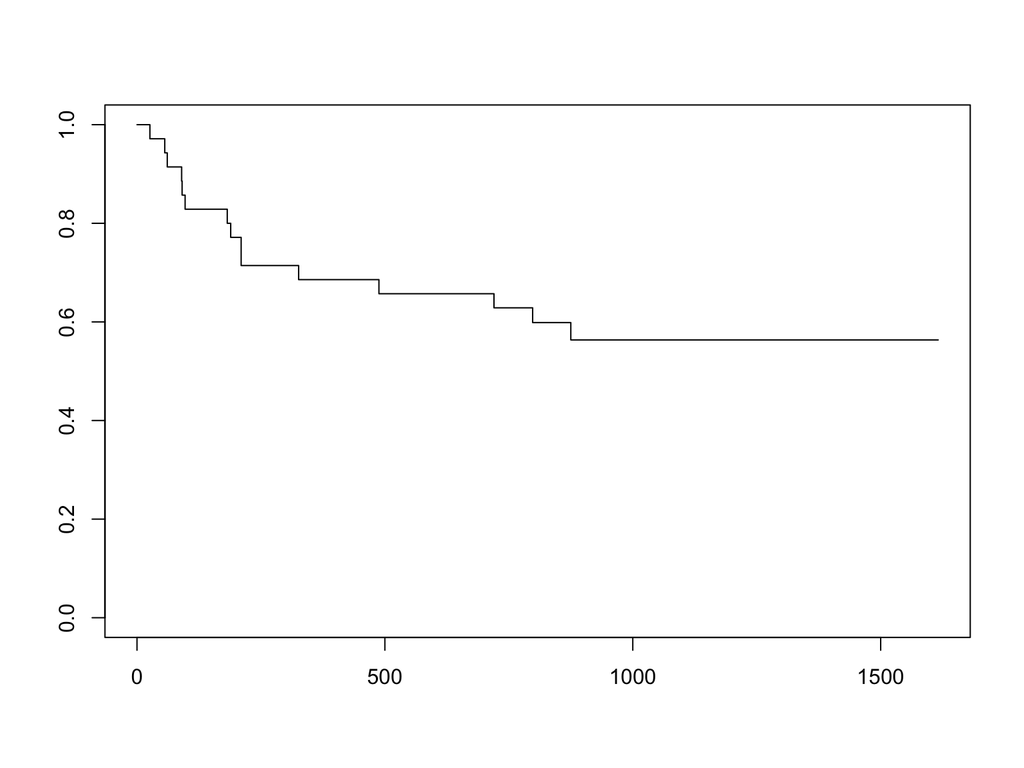

```
## Call: survfit(formula = Surv(time, event) ~ 1, data = .)
##
##  time n.risk n.event survival std.err lower 95% CI upper 95% CI
##    26     35       1    0.971  0.0282        0.918        1.000
##    56     34       1    0.943  0.0392        0.869        1.000
##    61     33       1    0.914  0.0473        0.826        1.000
##    90     32       1    0.886  0.0538        0.786        0.998
##    91     31       1    0.857  0.0591        0.749        0.981
##    97     30       1    0.829  0.0637        0.713        0.963
##   182     29       1    0.800  0.0676        0.678        0.944
##   189     28       1    0.771  0.0710        0.644        0.924
##   210     27       2    0.714  0.0764        0.579        0.881
##   326     25       1    0.686  0.0785        0.548        0.858
##   488     24       1    0.657  0.0802        0.517        0.835
##   720     23       1    0.629  0.0817        0.487        0.811
##   798     21       1    0.599  0.0831        0.456        0.786
##   875     17       1    0.563  0.0853        0.419        0.758
```

```r
library(survival)
lfuDate <- as.Date("12/31/2009", format = "%m/%d/%Y") ## last follow up date
## 1.
"data.csv" %>%
    readr::read_csv(
               col_types =
                   readr::cols(
                              txDate = readr::col_date( format = "%m/%d/%Y"),
                              eventDate = readr::col_date( format = "%m/%d/%Y"))
           ) %>%
    ## 2.
    dplyr::mutate(event = ifelse(!is.na(eventDate), 1, 0),
                  time = ifelse(!is.na(eventDate),
                                eventDate - txDate, lfuDate - txDate)) %>%
    ## 3. and 4
    survival::survfit(Surv(time, event) ~ 1, data = .) %T>%
    ## 5.
    plot(conf.int = FALSE) %>%
    ## 6.
    summary %>%
    ## 7.
    print
```

Here are the details.

1. Start from the name of the CSV file. Pipe that name to `readr::read_csv` to read a CSV file with specified date formats for variables `txDate` and `eventDate` since that is how they appear in the csv file
2. Create two new variables: `event`, indicating whether you saw an event or not, `time` indicating the time interval between the transplant and event date if an event was recorded, or the time interval between the transplant and last follow-up date
3. Fit a survival model. Since `survfit` expects the first argument to be the formula rather than the data set, we use the placeholder `.` to specify where the output of the previous step needs to be used. (In this particular case, another way to achieve the same effect finesse this would have been to use named arguments (`formula = Surv(time, event) ~ 1`) which would make data argument go in the right place since `data` happens to be the second argument of `survfit.formula`.)
4. The result of the call to `survfit` is to be plotted and summarized. So the `survfit` object is the argument to both the plotting and summary functions. The `%T>%` operator works like `%>%` but it returns the left hand size of the piping operation, that is, the input. So this ensures that both `plot` and `summary` get the `survfit` object as input in 5 and 6 noted in the code. This construct is used when you are interested in the *side effect* of calling a function rather than its output
5. When a function expects one argument, you can omit the empty parenthesis, for example, `print`.

# 4.2.4. Robustness

Functions in the `magrittr` package will not confuse `.` with a placeholder. For example, consider this from the `magrittr` vignette:

```r
car_data <-
  mtcars %>%
  subset(hp > 100) %>%
  aggregate(. ~ cyl, data = ., FUN = . %>% mean %>% round(2)) %>%
  transform(kpl = mpg %>% multiply_by(0.4251)) %>%
  print
```

```
##   cyl   mpg   disp     hp drat   wt  qsec   vs   am gear carb       kpl
## 1   4 25.90 108.05 111.00 3.94 2.15 17.75 1.00 1.00 4.50 2.00 11.010090
## 2   6 19.74 183.31 122.29 3.59 3.12 17.98 0.57 0.43 3.86 3.43  8.391474
## 3   8 15.10 353.10 209.21 3.23 4.00 16.77 0.00 0.14 3.29 3.50  6.419010
```

In the call to `aggregate`, the `.` is used as a placeholder for defining a function. Specifically, a pipeline with a dot (`.`) as LHS will create a unary function. If you did not use the `magrittr` feature, you’d have to do something like:

```r
aggregate(. ~ cyl,
          data = mtcars,
          FUN = function(x) round(mean(x), 2),
          subset = hp > 100
          )
```

```
##   cyl   mpg   disp     hp drat   wt  qsec   vs   am gear carb
## 1   4 25.90 108.05 111.00 3.94 2.15 17.75 1.00 1.00 4.50 2.00
## 2   6 19.74 183.31 122.29 3.59 3.12 17.98 0.57 0.43 3.86 3.43
## 3   8 15.10 353.10 209.21 3.23 4.00 16.77 0.00 0.14 3.29 3.50
```

which takes a bit more effort to parse.

### Carried away?

```r
set.seed(123)
1:3 %>%
    lapply(., FUN = . %>% rnorm)
```

```
## [[1]]
## [1] -0.5604756
##
## [[2]]
## [1] -0.2301775  1.5587083
##
## [[3]]
## [1] 0.07050839 0.12928774 1.71506499
```

```r
1:3 %>%
    lapply(., FUN = . %>% rnorm(10)) %>%
    sapply(., FUN = mean)
```

```
## [1] 10.460916  9.024043 10.379411
```

I don’t believe these are any great improvements.

# 4.2.5 References

- R for Data Science has a neat intro to pipes in [Chapter 18](https://r4ds.had.co.nz/pipes.html)
- See also the vignettes of the package [`magrittr`](https://cran.r-project.org/package=magrittr)